# Tidycensus will convince you to learn R

## How to get this table from data.census.gov

[figure not shown]

## How the table looks from census.gov

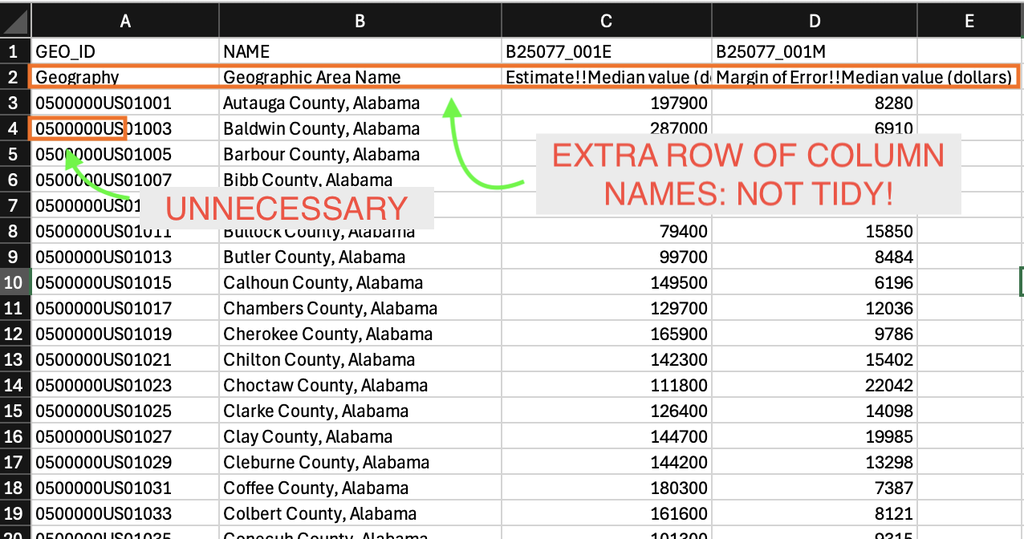

## 1-year ACS data

- 1-year ACS data are more current, but are only available for geographies of population 65,000 and greater
- Access 1-year ACS data with the argument `survey = "acs1"`; defaults to `"acs5"`

```r
median_value_1yr <- get_acs(
  geography = "place",
  variables = "B25077_001", # median value of homes
  year = 2022,
  survey = "acs1"
)
```

```r
median_value_1yr
```

```
# A tibble: 646 × 5
   GEOID   NAME                           variable   estimate   moe
   <chr>   <chr>                          <chr>         <dbl> <dbl>
 1 0103076 Auburn city, Alabama           B25077_001   335200 22622
 2 0107000 Birmingham city, Alabama       B25077_001   125500 14964
 3 0121184 Dothan city, Alabama           B25077_001   190800  8133
 4 0135896 Hoover city, Alabama           B25077_001   393400 19743
 5 0137000 Huntsville city, Alabama       B25077_001   294700 16881
 6 0150000 Mobile city, Alabama           B25077_001   178800 11552
 7 0151000 Montgomery city, Alabama       B25077_001   155200 10868
 8 0177256 Tuscaloosa city, Alabama       B25077_001   297600 30475
 9 0203000 Anchorage municipality, Alaska B25077_001   367900 10111
10 0404720 Avondale city, Arizona         B25077_001   400300 22495
# ℹ 636 more rows
```

# Understanding variables and geograpy in tidycensus

## Searching for variables

- A good guide on available tables of variables is on [CensusReporter.org](https://censusreporter.org/topics/table-codes/)
- To search for variables, use the `load_variables()` function along with a year and dataset
- The `View()` function in RStudio allows for interactive browsing and filtering

```r
vars <- load_variables(2022, "acs5")
```

```r
View(vars)
```

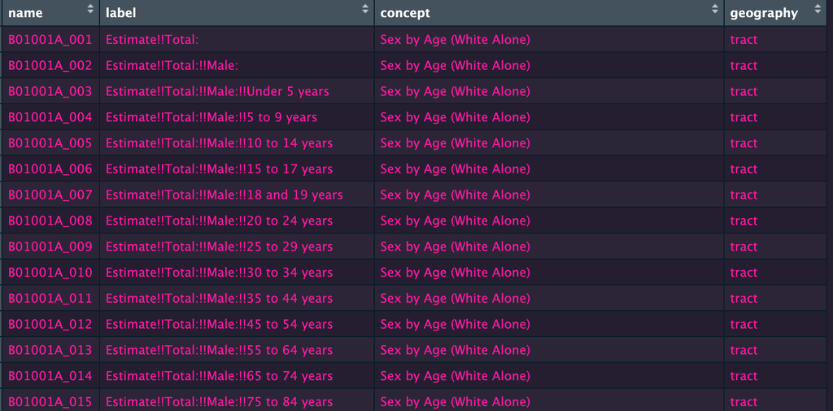

## Search for “coupled households” in the search bar

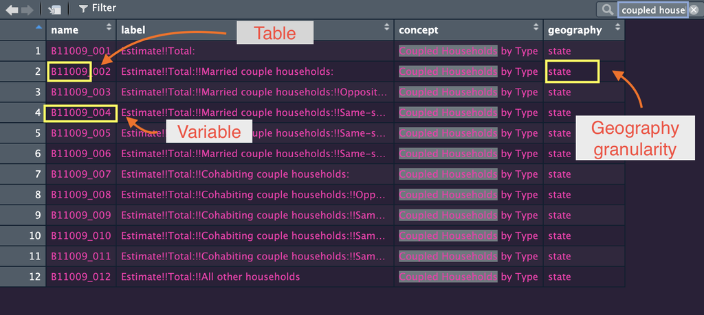

## Requesting tables of variables

- The `table` parameter can be used to obtain all related variables in a “table” at once

```r
couples_table <- get_acs(
  geography = "state",
  table = "B11009",
  year = 2022
)
```

```r
couples_table
```

```
# A tibble: 624 × 5
   GEOID NAME    variable   estimate   moe
   <chr> <chr>   <chr>         <dbl> <dbl>
 1 01    Alabama B11009_001  1933150  5364
 2 01    Alabama B11009_002   906990  6556
 3 01    Alabama B11009_003   901145  6486
 4 01    Alabama B11009_004     5845   500
 5 01    Alabama B11009_005     2532   414
 6 01    Alabama B11009_006     3313   430
 7 01    Alabama B11009_007    91601  3154
 8 01    Alabama B11009_008    87318  3083
 9 01    Alabama B11009_009     4283   572
10 01    Alabama B11009_010     1989   373
# ℹ 614 more rows
```

## Using named vectors of variables

- Census variables can be hard to remember; using a named vector to request variables will replace the Census IDs with a custom input
- In long form, these custom inputs will populate the `variable` column; in wide form, they will replace the column names

## Renaming variables easily

```r
couples_table_selected <- get_acs(
  geography = "state",
  variables = c(married_total = "B11009_002",
                married_opposite_sex = "B11009_003",
                married_same_sex = "B11009_004",
                married_male_male = "B11009_005",
                married_female_female = "B11009_006"),
  year = 2022
)
```

```r
couples_table_selected
```

```
# A tibble: 260 × 5
   GEOID NAME    variable              estimate   moe
   <chr> <chr>   <chr>                    <dbl> <dbl>
 1 01    Alabama married_total           906990  6556
 2 01    Alabama married_opposite_sex    901145  6486
 3 01    Alabama married_same_sex          5845   500
 4 01    Alabama married_male_male         2532   414
 5 01    Alabama married_female_female     3313   430
 6 02    Alaska  married_total           129605  1689
 7 02    Alaska  married_opposite_sex    128659  1660
 8 02    Alaska  married_same_sex           946   229
 9 02    Alaska  married_male_male          338   133
10 02    Alaska  married_female_female      608   175
# ℹ 250 more rows
```

## US Census Geography

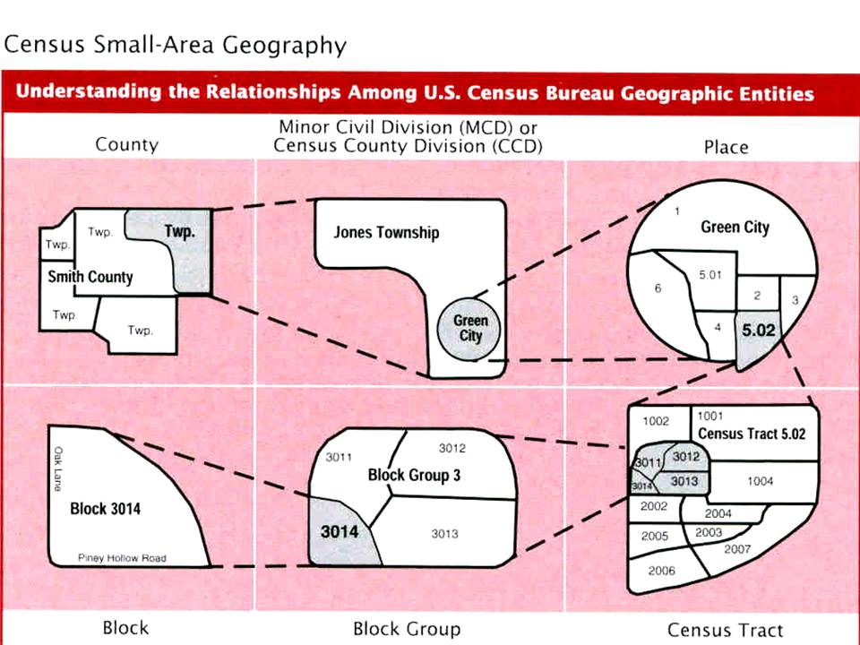

## Geography in tidycensus

- Information on available geographies, and how to specify them, can be found [in the tidycensus documentation](https://walker-data.com/tidycensus/articles/basic-usage.html#geography-in-tidycensus-1)

| Geography | Definition | Available by | Available in |
| --- | --- | --- | --- |
| `"us"` | United States |  | `get_acs()`, `get_decennial()` |
| `"region"` | Census region |  | `get_acs()`, `get_decennial()` |
| `"division"` | Census division |  | `get_acs()`, `get_decennial()` |
| `"state"` | State or equivalent | state | `get_acs()`, `get_decennial()` |
| `"county"` | County or equivalent | state, county | `get_acs()`, `get_decennial()` |
| `"county subdivision"` | County subdivision | state, county | `get_acs()`, `get_decennial()` |
| `"tract"` | Census tract | state, county | `get_acs()`, `get_decennial()` |
| `"block group"` OR `"cbg"` | Census block group | state, county | `get_acs()`, `get_decennial()` |

## Querying by state

- For geographies available below the state level, the `state` parameter allows you to query data for a specific state
- For smaller geographies (Census tracts, block groups), a `county` argument may also need to be included
- **tidycensus** translates state names and postal abbreviations internally, so you don’t need to remember the FIPS codes!

## Querying tract data requires county and state

- Example: data on median home value in Los Angeles County, California by Census tract

```r
la_value <- get_acs(
  geography = "tract",
  variables = "B25077_001",
  state = "CA",
  county = "Los Angeles",
  year = 2023
)
```

```r
la_value
```

```
# A tibble: 2,498 × 5
   GEOID       NAME                                     variable estimate    moe
   <chr>       <chr>                                    <chr>       <dbl>  <dbl>
 1 06037101110 Census Tract 1011.10; Los Angeles Count… B25077_…   739600  82108
 2 06037101122 Census Tract 1011.22; Los Angeles Count… B25077_…   917600  33720
 3 06037101220 Census Tract 1012.20; Los Angeles Count… B25077_…   734700  75970
 4 06037101221 Census Tract 1012.21; Los Angeles Count… B25077_…   553500  82593
 5 06037101222 Census Tract 1012.22; Los Angeles Count… B25077_…   585500 566191
 6 06037101300 Census Tract 1013; Los Angeles County; … B25077_…   890900  43180
 7 06037101400 Census Tract 1014; Los Angeles County; … B25077_…   799200 106267
 8 06037102103 Census Tract 1021.03; Los Angeles Count… B25077_…   821300  83237
 9 06037102104 Census Tract 1021.04; Los Angeles Count… B25077_…   745800  97490
10 06037102105 Census Tract 1021.05; Los Angeles Count… B25077_…   731800 112466
# ℹ 2,488 more rows
```

## Available ACS datasets in tidycensus

- Detailed Tables
- Data Profile (add `"/profile"` for variable lookup)
- Subject Tables (add `"/subject"`)
- Comparison Profile (add `"/cprofile"`)
- Supplemental Estimates (use `"acsse"`)
- Migration Flows (access with `get_flows()`)

## “Tidy” or long-form data

- The default data structure returned by **tidycensus** is “tidy” or long-form data, with variables by geography stacked by row

```r
age_sex_table <- get_acs(
  geography = "state",
  table = "B01001",
  year = 2022,
  survey = "acs1",
)
```

```r
age_sex_table
```

```
# A tibble: 2,548 × 5
   GEOID NAME    variable   estimate   moe
   <chr> <chr>   <chr>         <dbl> <dbl>
 1 01    Alabama B01001_001  5074296    NA
 2 01    Alabama B01001_002  2461248  6178
 3 01    Alabama B01001_003   146169  3134
 4 01    Alabama B01001_004   158767  6029
 5 01    Alabama B01001_005   164578  5689
 6 01    Alabama B01001_006    97834  3029
 7 01    Alabama B01001_007    70450  2897
 8 01    Alabama B01001_008    42597  4156
 9 01    Alabama B01001_009    34623  3440
10 01    Alabama B01001_010    97373  4627
# ℹ 2,538 more rows
```

## “Wide” data

- The argument `output = "wide"` spreads Census variables across the columns, returning one row per geographic unit and one column per variable

```r
age_sex_table_wide <- get_acs(
  geography = "state",
  table = "B01001",
  year = 2022,
  survey = "acs1",
  output = "wide"
)
```

```r
age_sex_table_wide
```

```
# A tibble: 52 × 100
   GEOID NAME        B01001_001E B01001_001M B01001_002E B01001_002M B01001_003E
   <chr> <chr>             <dbl>       <dbl>       <dbl>       <dbl>       <dbl>
 1 01    Alabama         5074296          NA     2461248        6178      146169
 2 02    Alaska           733583          NA      385667        2351       23043
 3 04    Arizona         7359197          NA     3678381        2695      201423
 4 05    Arkansas        3045637          NA     1504488        4216       90239
 5 06    California     39029342          NA    19536425        6410     1081904
 6 08    Colorado        5839926          NA     2960896        4278      154565
 7 09    Connecticut     3626205          NA     1776689        2237       91513
 8 10    Delaware        1018396          NA      494657        1092       27456
 9 11    District o…      671803          NA      319763         733       20038
10 12    Florida        22244823          NA    10953468        6169      563703
# ℹ 42 more rows
# ℹ 93 more variables: B01001_003M <dbl>, B01001_004E <dbl>, B01001_004M <dbl>,
#   B01001_005E <dbl>, B01001_005M <dbl>, B01001_006E <dbl>, B01001_006M <dbl>,
#   B01001_007E <dbl>, B01001_007M <dbl>, B01001_008E <dbl>, B01001_008M <dbl>,
#   B01001_009E <dbl>, B01001_009M <dbl>, B01001_010E <dbl>, B01001_010M <dbl>,
#   B01001_011E <dbl>, B01001_011M <dbl>, B01001_012E <dbl>, B01001_012M <dbl>,
#   B01001_013E <dbl>, B01001_013M <dbl>, B01001_014E <dbl>, …
```

# ACS data warnings

## Understanding limitations of the 1-year ACS

- The 1-year American Community Survey is only available for geographies with population 65,000 and greater. This means:
- Only 848 of 3,221 counties are available
- Only 646 of 31,908 cities / Census-designated places are available
- No data for Census tracts, block groups, ZCTAs, or any other geographies that typically have populations below 65,000

## Data sparsity and margins of error

- You may encounter data issues in the 1-year ACS data that are less pronounced in the 5-year ACS. For example:
- Values available in the 5-year ACS may not be available in the corresponding 1-year ACS tables
- If available, they will likely have larger margins of error
- Your job as an data journalist: balance need for *certainty* vs. need for *recency* in estimates

## Somali speakers by state (1-year ACS)

```r
get_acs(
  geography = "state",
  variables = "B16001_111",
  year = 2023,
  survey = "acs1"
)
```

```
# A tibble: 52 × 5
   GEOID NAME                 variable   estimate   moe
   <chr> <chr>                <chr>         <dbl> <dbl>
 1 01    Alabama              B16001_111       49    57
 2 02    Alaska               B16001_111       NA    NA
 3 04    Arizona              B16001_111    11841  4464
 4 05    Arkansas             B16001_111      331   433
 5 06    California           B16001_111    55705  6237
 6 08    Colorado             B16001_111    15546  3487
 7 09    Connecticut          B16001_111     1090   671
 8 10    Delaware             B16001_111       29    64
 9 11    District of Columbia B16001_111     7744  3113
10 12    Florida              B16001_111     5001  2590
# ℹ 42 more rows
```

## Somali speakers by state (5-year ACS)

```r
get_acs(
  geography = "state",
  variables = "B16001_111",
  year = 2023,
  survey = "acs5"
)
```

```
# A tibble: 52 × 5
   GEOID NAME                 variable   estimate   moe
   <chr> <chr>                <chr>         <dbl> <dbl>
 1 01    Alabama              B16001_111      351   210
 2 02    Alaska               B16001_111      378   196
 3 04    Arizona              B16001_111    10564  1554
 4 05    Arkansas             B16001_111      105    81
 5 06    California           B16001_111    63093  3649
 6 08    Colorado             B16001_111    17728  2029
 7 09    Connecticut          B16001_111     1415   499
 8 10    Delaware             B16001_111      252   179
 9 11    District of Columbia B16001_111     6948  1284
10 12    Florida              B16001_111     5429  1577
# ℹ 42 more rows
```

## Other warnings

- Variables in the Data Profile and Subject Tables can change names over time
- The 2022 ACS is the first to include the new Connecticut Planning Regions in the “county” geography
- The 2020 1-year ACS was not released (and is not in tidycensus), so your time-series can break if you are using iteration to pull data

# The 2020 Decennial US Census data and R

## What is the decennial US Census?

- Complete count of the US population mandated by Article 1, Sections 2 and 9 in the US Constitution
- Directed by the US Census Bureau (US Department of Commerce); conducted every 10 years since 1790
- Used for proportional representation / congressional redistricting
- Limited set of questions asked about race, ethnicity, age, sex, and housing tenure

## 2020 US Census datasets

- The PL 94-171 Redistricting Data
- The Demographic and Housing Characteristics (DHC) file
- The Demographic Profile (for pre-tabulated variables)
- Tabulations for the 118th Congress & for Island Areas
- The Detailed DHC-A file (with very detailed racial & ethnic categories)

## 2020 US Census in Tidycensus

- The `get_decennial()` function is used to acquire data from the decennial US Census
- The two required arguments are `geography` and `variables` for the functions to work; for 2020 Census data, use `year = 2020`.

```r
pop20 <- get_decennial(
  geography = "state",
  variables = "P1_001N",
  year = 2020
)
```

- Decennial Census data are returned with four columns: GEOID, NAME, variable, and value

```r
pop20
```

```
# A tibble: 52 × 4
   GEOID NAME                 variable    value
   <chr> <chr>                <chr>       <dbl>
 1 42    Pennsylvania         P1_001N  13002700
 2 06    California           P1_001N  39538223
 3 54    West Virginia        P1_001N   1793716
 4 49    Utah                 P1_001N   3271616
 5 36    New York             P1_001N  20201249
 6 11    District of Columbia P1_001N    689545
 7 02    Alaska               P1_001N    733391
 8 12    Florida              P1_001N  21538187
 9 45    South Carolina       P1_001N   5118425
10 38    North Dakota         P1_001N    779094
# ℹ 42 more rows
```

## Differential privacy

- When we run `get_decennial()` for the 2020 Census for the first time, we see the following messages:

```
Using the PL 94-171 Redistricting Data summary file
Note: 2020 decennial Census data use differential privacy, a technique that
introduces errors into data to preserve respondent confidentiality.
ℹ Small counts should be interpreted with caution.
ℹ See https://www.census.gov/library/fact-sheets/2021/protecting-the-confidentiality-of-the-2020-census-redistricting-data.html for additional guidance.
```

## What is differential privacy?

- The Census Bureau is using *differential privacy* in an attempt to preserve respondent confidentiality in the 2020 Census data, which is required under US Code Title 13
- Intentional errors are introduced into data, impacting the accuracy of small area counts (e.g. some blocks with children, but no adults)
- Advocates argue that differential privacy is necessary to satisfy Title 13 requirements given modern database reconstruction technologies; critics contend that the method makes data less useful with no tangible privacy benefit

# Wrangling and analyzing Census data

open 02_wrangling_census_data.R in RStudio

## Tidycensus functions

The basics to wrangle data

- `filter()` gets rid of rows
- `mutate()` adds columns to the dataframe
- `group_by()` and `summarize()` will aggregate the data by groups
- `arrange()` will sort the data
- `select()` will help narrow down columns
- Daisy chain all these functions together with `|>`

## Case study: Racial plurality by county

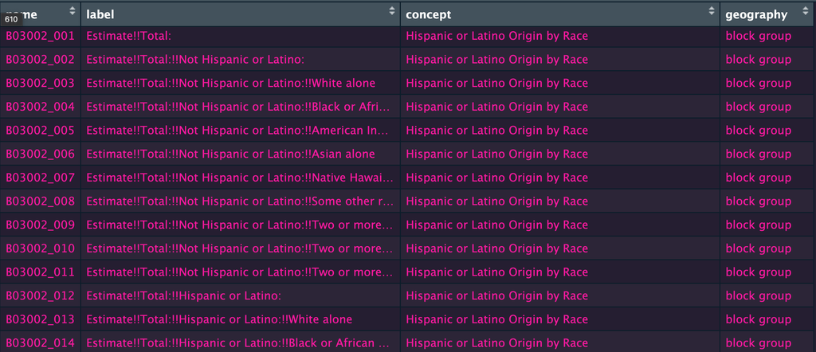

```r
View(vars) # and search for Hispanic or Latino Origin by Race
```

## Download race Census data

```r
county_diversity <- get_acs(geography = "county",
                            variables = c("B03002_001", # total
                                          "B03002_003", # white alone
                                          "B03002_004", # black alone
                                          "B03002_005", # native american
                                          "B03002_006", # asian alone
                                          "B03002_007", # pi alone
                                          "B03002_012" # hispanic or latino
                            ),
                            survey="acs5",
                            year=2022)
```

```r
county_diversity
```

```
# A tibble: 22,554 × 5
   GEOID NAME                    variable   estimate   moe
   <chr> <chr>                   <chr>         <dbl> <dbl>
 1 01001 Autauga County, Alabama B03002_001    58761    NA
 2 01001 Autauga County, Alabama B03002_003    42635   224
 3 01001 Autauga County, Alabama B03002_004    11496   525
 4 01001 Autauga County, Alabama B03002_005       59    71
 5 01001 Autauga County, Alabama B03002_006      636   213
 6 01001 Autauga County, Alabama B03002_007        0    30
 7 01001 Autauga County, Alabama B03002_012     1864    NA
 8 01003 Baldwin County, Alabama B03002_001   233420    NA
 9 01003 Baldwin County, Alabama B03002_003   192161  1020
10 01003 Baldwin County, Alabama B03002_004    19318   730
# ℹ 22,544 more rows
```

## Add a total population column

- With an argument `summary_var`

```r
county_diversity <- get_acs(geography = "county",
                            variables = c("B03002_003", # white alone
                                          "B03002_004", # black alone
                                          "B03002_005", # native american
                                          "B03002_006", # asian alone
                                          "B03002_007", # pi alone
                                          "B03002_012" # hispanic or latino
                            ),
                            summary_var = "B03002_001", # total population
                            survey="acs5",
                            year=2022)
```

```r
county_diversity
```

```
# A tibble: 19,332 × 7
   GEOID NAME                    variable estimate   moe summary_est summary_moe
   <chr> <chr>                   <chr>       <dbl> <dbl>       <dbl>       <dbl>
 1 01001 Autauga County, Alabama B03002_…    42635   224       58761          NA
 2 01001 Autauga County, Alabama B03002_…    11496   525       58761          NA
 3 01001 Autauga County, Alabama B03002_…       59    71       58761          NA
 4 01001 Autauga County, Alabama B03002_…      636   213       58761          NA
 5 01001 Autauga County, Alabama B03002_…        0    30       58761          NA
 6 01001 Autauga County, Alabama B03002_…     1864    NA       58761          NA
 7 01003 Baldwin County, Alabama B03002_…   192161  1020      233420          NA
 8 01003 Baldwin County, Alabama B03002_…    19318   730      233420          NA
 9 01003 Baldwin County, Alabama B03002_…      512   187      233420          NA
10 01003 Baldwin County, Alabama B03002_…     2046   347      233420          NA
# ℹ 19,322 more rows
```

## Add a percent column

- Using the **dplyr** library of data wrangling functions
- `mutate()` to add a new column to the data frame

```r
library(dplyr)

county_diversity <- county_diversity |>
  mutate(percent=estimate/summary_est*100)
```

```r
county_diversity
```

```
# A tibble: 19,332 × 7
   GEOID NAME                    variable   estimate   moe summary_est percent
   <chr> <chr>                   <chr>         <dbl> <dbl>       <dbl>   <dbl>
 1 01001 Autauga County, Alabama B03002_003    42635   224       58761  72.6
 2 01001 Autauga County, Alabama B03002_004    11496   525       58761  19.6
 3 01001 Autauga County, Alabama B03002_005       59    71       58761   0.100
 4 01001 Autauga County, Alabama B03002_006      636   213       58761   1.08
 5 01001 Autauga County, Alabama B03002_007        0    30       58761   0
 6 01001 Autauga County, Alabama B03002_012     1864    NA       58761   3.17
 7 01003 Baldwin County, Alabama B03002_003   192161  1020      233420  82.3
 8 01003 Baldwin County, Alabama B03002_004    19318   730      233420   8.28
 9 01003 Baldwin County, Alabama B03002_005      512   187      233420   0.219
10 01003 Baldwin County, Alabama B03002_006     2046   347      233420   0.877
# ℹ 19,322 more rows
```

## Add better variable names

- `case_when()` to refactor values (within `mutate()`)
- `.default` is **else** or if none of the factors match
- `|>` are the new pipes, aka “and then”

```r
county_diversity_race <- county_diversity |>
  mutate(race=case_when(
    variable=="B03002_003" ~"White",
    variable=="B03002_004" ~"Black",
    variable=="B03002_005" ~"Native American",
    variable=="B03002_006" ~"Asian",
    variable=="B03002_007" ~"Pacific Islander",
    variable=="B03002_012" ~"Hispanic",
    .default = "Other"
  ))
```

```r
county_diversity_race
```

```
# A tibble: 19,332 × 6
   GEOID NAME                    estimate summary_est percent race
   <chr> <chr>                      <dbl>       <dbl>   <dbl> <chr>
 1 01001 Autauga County, Alabama    42635       58761  72.6   White
 2 01001 Autauga County, Alabama    11496       58761  19.6   Black
 3 01001 Autauga County, Alabama       59       58761   0.100 Native American
 4 01001 Autauga County, Alabama      636       58761   1.08  Asian
 5 01001 Autauga County, Alabama        0       58761   0     Pacific Islander
 6 01001 Autauga County, Alabama     1864       58761   3.17  Hispanic
 7 01003 Baldwin County, Alabama   192161      233420  82.3   White
 8 01003 Baldwin County, Alabama    19318      233420   8.28  Black
 9 01003 Baldwin County, Alabama      512      233420   0.219 Native American
10 01003 Baldwin County, Alabama     2046      233420   0.877 Asian
# ℹ 19,322 more rows
```

## Group up some smaller groups

- use `group_by()` to group up things
- use `summarize()` to do something (usually math) on these groups
- Let’s combine the population for Asian and Pacific Islander

## Group up some smaller groups code

```r
county_diversity_percent <- county_diversity |>
  mutate(race=case_when(
    variable=="B03002_003" ~"White",
    variable=="B03002_004" ~"Black",
    variable=="B03002_005" ~"Native American",
    variable=="B03002_006" ~"Asian Pacific Islander",
    variable=="B03002_007" ~"Asian Pacific Islander",
    variable=="B03002_012" ~"Hispanic",
    .default = "Other"
  )) |>
  group_by(GEOID, NAME, race) |>
  summarize(estimate=sum(estimate, na.rm=T),
            summary_est=mean(summary_est, na.rm=T)) |>
  mutate(percent=estimate/summary_est*100)
```

```r
county_diversity_percent
```

```
# A tibble: 16,110 × 5
   NAME                    race                   estimate summary_est percent
   <chr>                   <chr>                     <dbl>       <dbl>   <dbl>
 1 Autauga County, Alabama Asian Pacific Islander      636       58761   1.08
 2 Autauga County, Alabama Black                     11496       58761  19.6
 3 Autauga County, Alabama Hispanic                   1864       58761   3.17
 4 Autauga County, Alabama Native American              59       58761   0.100
 5 Autauga County, Alabama White                     42635       58761  72.6
 6 Baldwin County, Alabama Asian Pacific Islander     2068      233420   0.886
 7 Baldwin County, Alabama Black                     19318      233420   8.28
 8 Baldwin County, Alabama Hispanic                  11210      233420   4.80
 9 Baldwin County, Alabama Native American             512      233420   0.219
10 Baldwin County, Alabama White                    192161      233420  82.3
# ℹ 16,100 more rows
```

## Sort the data frame low to high

- Use the `arrange()` function

```r
county_diversity_percent |>
  group_by(NAME) |>
  arrange(NAME, percent)
```

```
# A tibble: 16,110 × 4
   NAME                             race                   estimate percent
   <chr>                            <chr>                     <dbl>   <dbl>
 1 Abbeville County, South Carolina Native American              28  0.115
 2 Abbeville County, South Carolina Asian Pacific Islander       58  0.238
 3 Abbeville County, South Carolina Hispanic                    441  1.81
 4 Abbeville County, South Carolina Black                      6372 26.1
 5 Abbeville County, South Carolina White                     16658 68.4
 6 Acadia Parish, Louisiana         Native American              13  0.0225
 7 Acadia Parish, Louisiana         Asian Pacific Islander       95  0.165
 8 Acadia Parish, Louisiana         Hispanic                   1780  3.09
 9 Acadia Parish, Louisiana         Black                      9511 16.5
10 Acadia Parish, Louisiana         White                     44413 77.0
# ℹ 16,100 more rows
```

## Sort the data frame high to low

- Use the `arrange()` function
- Use the `desc()` function

```r
county_diversity_percent_sorted <- county_diversity_percent |>
  group_by(NAME) |>
  arrange(NAME, desc(percent))
```

```r
county_diversity_percent_sorted
```

```
# A tibble: 16,110 × 5
   NAME                             race            estimate summary_est percent
   <chr>                            <chr>              <dbl>       <dbl>   <dbl>
 1 Abbeville County, South Carolina White              16658       24368 68.4
 2 Abbeville County, South Carolina Black               6372       24368 26.1
 3 Abbeville County, South Carolina Hispanic             441       24368  1.81
 4 Abbeville County, South Carolina Asian Pacific …       58       24368  0.238
 5 Abbeville County, South Carolina Native American       28       24368  0.115
 6 Acadia Parish, Louisiana         White              44413       57674 77.0
 7 Acadia Parish, Louisiana         Black               9511       57674 16.5
 8 Acadia Parish, Louisiana         Hispanic            1780       57674  3.09
 9 Acadia Parish, Louisiana         Asian Pacific …       95       57674  0.165
10 Acadia Parish, Louisiana         Native American       13       57674  0.0225
# ℹ 16,100 more rows
```

Notice there are 16,110 rows…

## Narrow down the rows

- We want one row for every county
- Use the `filter()` function

```r
county_diversity_percent_plurality <-
  county_diversity_percent |>
  group_by(NAME) |>
  arrange(NAME, desc(percent)) |>
  filter(row_number()==1)
```

```r
county_diversity_percent_plurality
```

```
# A tibble: 3,222 × 5
   NAME                             race            estimate summary_est percent
   <chr>                            <chr>              <dbl>       <dbl>   <dbl>
 1 Abbeville County, South Carolina White              16658       24368    68.4
 2 Acadia Parish, Louisiana         White              44413       57674    77.0
 3 Accomack County, Virginia        White              19813       33367    59.4
 4 Ada County, Idaho                White             411348      497494    82.7
 5 Adair County, Iowa               White               7046        7479    94.2
 6 Adair County, Kentucky           White              17308       18887    91.6
 7 Adair County, Missouri           White              22367       25299    88.4
 8 Adair County, Oklahoma           Native American     8468       19726    42.9
 9 Adams County, Colorado           White             247045      520149    47.5
10 Adams County, Idaho              White               4009        4464    89.8
# ℹ 3,212 more rows
```

Now there are 3,222 rows.

Which lines up with the county count in the U.S.

## Narrow down the rows II

- Use the `slice()` function

```r
county_diversity_percent_plurality <-
  county_diversity_percent |>
  group_by(NAME) |>
  arrange(NAME, desc(percent)) |>
  slice(1)
```

## Case study: Evictions in San Diego

```r
sd_evictions <- read_csv("san_diego_evictions.csv")

sd_evictions
```

```
# A tibble: 736 × 2
   GEOID       total_evictions
   <chr>                 <dbl>
 1 06073000100               1
 2 06073000201               2
 3 06073000202               4
 4 06073000301               2
 5 06073000302              10
 6 06073000400               6
 7 06073000500               3
 8 06073000600               2
 9 06073000700               3
10 06073000800              20
# ℹ 726 more rows
```

## Go back and modify your code

Copy and paste over the code you worked so hard on and change the geography and add state and county.

```r
sd_tract_diversity <- get_acs(geography = "tract",
                              state = "California",
                              county = "San Diego",
                            variables = c("B03002_003", # white alone
                                          "B03002_004", # black alone
                                          "B03002_005", # native american
                                          "B03002_006", # asian alone
                                          "B03002_007", # pi alone
                                          "B03002_012" # hispanic or latino
                            ),
                            summary_var = "B03002_001", # total population
                            survey="acs5",
                            year=2022)
```

## Wrangle the census tract data

Nothing changes except the names of the data frames

```r
sd_tract_diversity_plurality <- sd_tract_diversity |>
  mutate(race=case_when(
      variable=="B03002_003" ~"White",
      variable=="B03002_004" ~"Black",
      variable=="B03002_005" ~"Native American",
      variable=="B03002_006" ~"Asian Pacific Islander",
      variable=="B03002_007" ~"Asian Pacific Islander",
      variable=="B03002_012" ~"Hispanic",
      .default = "Other"
    )) |>
  group_by(GEOID, NAME, race) |>
  summarize(estimate=sum(estimate, na.rm=T),
            summary_est=mean(summary_est, na.rm=T)) |>
  mutate(percent=estimate/summary_est*100) |>
  group_by(GEOID, NAME) |>
  arrange(GEOID, NAME, desc(percent)) |>
  slice(1)
```

```r
sd_tract_diversity_plurality
```

```
# A tibble: 737 × 5
   GEOID       race  estimate summary_est percent
   <chr>       <chr>    <dbl>       <dbl>   <dbl>
 1 06073000100 White     2116        3027    69.9
 2 06073000201 White     1926        2294    84.0
 3 06073000202 White     2873        3919    73.3
 4 06073000301 White     1331        2340    56.9
 5 06073000302 White     2182        2934    74.4
 6 06073000400 White     1984        3802    52.2
 7 06073000500 White     2002        2934    68.2
 8 06073000600 White     2044        3144    65.0
 9 06073000700 White     2934        4631    63.4
10 06073000800 White     3097        5257    58.9
# ℹ 727 more rows
```

## Join data

- Using `inner_join()` from **dplyr**

```r
sd_joined <- inner_join(sd_tract_diversity_plurality, sd_evictions)

sd_joined
```

```
# A tibble: 736 × 6
   GEOID       race  estimate summary_est percent total_evictions
   <chr>       <chr>    <dbl>       <dbl>   <dbl>           <dbl>
 1 06073000100 White     2116        3027    69.9               1
 2 06073000201 White     1926        2294    84.0               2
 3 06073000202 White     2873        3919    73.3               4
 4 06073000301 White     1331        2340    56.9               2
 5 06073000302 White     2182        2934    74.4              10
 6 06073000400 White     1984        3802    52.2               6
 7 06073000500 White     2002        2934    68.2               3
 8 06073000600 White     2044        3144    65.0               2
 9 06073000700 White     2934        4631    63.4               3
10 06073000800 White     3097        5257    58.9              20
# ℹ 726 more rows
```

## Summarize the evictions data

Now you can answer which neighborhoods in San Diego had the higher eviction rates.

```r
sd_joined |>
  group_by(race) |>
  summarize(population=sum(summary_est, na.rm=T),
            total_evictions=sum(total_evictions, na.rm=T)) |>
  mutate(rate_of_evictions=total_evictions/population*1000) |>
  arrange(desc(rate_of_evictions))
```

```
# A tibble: 4 × 4
  race                   population total_evictions rate_of_evictions
  <chr>                       <dbl>           <dbl>             <dbl>
1 Black                          36               1             27.8
2 Hispanic                  1123001            2121              1.89
3 White                     1968310            2816              1.43
4 Asian Pacific Islander     198354             212              1.07
```

# Common Census queries

open 03_common_census_queries.R in RStudio

## Example of iterating with loops

Here’s a basic “for loop” which includes setting the limits for the loop to 10.

```r
for (i in 1:10) {
  print(i)
}
```

```
[1] 1
[1] 2
[1] 3
[1] 4
[1] 5
[1] 6
[1] 7
[1] 8
[1] 9
[1] 10
```

## Explaining loops in R

- Manually, this would have looked like `print(1)` then `print(2)` then `print(3)` one by one.
- Each loop iterates the `i` within the established limits (**1:10**)
- But this is a way to run code many times with slight variations to a value or values in the code. It all goes between the `{` and `}`.

## Multiple years of Census data

- Set up a way to append new data to the original data

```r
big_census_data <- tibble() # creates a blank data frame

for (i in 2020:2022) {
  median_df <- get_acs( # temporary dataframe
    geography = "county",
    variables = "B25077_001", # median home values
    year = i
    ) |>
    mutate(year = i) # so we can identify which year

  big_census_data <- bind_rows(big_census_data, median_df) |>
    arrange(GEOID, year)
  # appends the temporary dataframe to the permanent one
}
```

```r
big_census_data
```

```
# A tibble: 9,664 × 6
   GEOID NAME                    variable   estimate   moe  year
   <chr> <chr>                   <chr>         <dbl> <dbl> <int>
 1 01001 Autauga County, Alabama B25077_001   161200  6652  2020
 2 01001 Autauga County, Alabama B25077_001   164900  6871  2021
 3 01001 Autauga County, Alabama B25077_001   191800  7996  2022
 4 01003 Baldwin County, Alabama B25077_001   211600  5853  2020
 5 01003 Baldwin County, Alabama B25077_001   226600  5984  2021
 6 01003 Baldwin County, Alabama B25077_001   266000  6916  2022
 7 01005 Barbour County, Alabama B25077_001    86500  9981  2020
 8 01005 Barbour County, Alabama B25077_001    89500 11054  2021
 9 01005 Barbour County, Alabama B25077_001   102700 11171  2022
10 01007 Bibb County, Alabama    B25077_001    96400 13625  2020
# ℹ 9,654 more rows
```

## Quickly calculate percent change

```r
library(tidyr)

home_value_change <- big_census_data |>
  ungroup() |>
  filter(year!=2021) |>
  select(NAME, estimate, year) |>
  pivot_wider(names_from="year", values_from="estimate") |>
  mutate(change=round((`2022`-`2020`)/`2020`*100,2)) |>
  arrange(desc(change))
```

```r
home_value_change
```

```
# A tibble: 3,230 × 4
   NAME                         `2020` `2022` change
   <chr>                         <dbl>  <dbl>  <dbl>
 1 Jackson County, South Dakota  58600 108400   85.0
 2 Crockett County, Texas       102200 181300   77.4
 3 Real County, Texas           146900 258000   75.6
 4 De Baca County, New Mexico   130000 219200   68.6
 5 Keya Paha County, Nebraska    65000 109000   67.7
 6 Daggett County, Utah         152500 252400   65.5
 7 Stewart County, Georgia       44100  72500   64.4
 8 Gem County, Idaho            198700 324700   63.4
 9 Shackelford County, Texas    110000 178500   62.3
10 Sterling County, Texas        75000 121000   61.3
# ℹ 3,220 more rows
```

## Looping through states to get tracts

```r
state_names <- c("DC", "MD", "VA") # Get a list of state names or abbreviations

tract_data <- tibble()
for (i in 1:length(state_names)) {
    tract_df <- get_acs(
    geography = "tract",
    variables = "B25077_001",
    year = 2022,
    state=state_names[i] # Swap out the state name in the array
    )

  tract_data <- bind_rows(tract_data, tract_df)
}
```

```r
tract_data
```

```
# A tibble: 3,879 × 5
   GEOID       NAME                                     variable estimate    moe
   <chr>       <chr>                                    <chr>       <dbl>  <dbl>
 1 11001000101 Census Tract 1.01; District of Columbia… B25077_…   635000 368769
 2 11001000102 Census Tract 1.02; District of Columbia… B25077_…  1382800 636468
 3 11001000201 Census Tract 2.01; District of Columbia… B25077_…       NA     NA
 4 11001000202 Census Tract 2.02; District of Columbia… B25077_…  1385700 124023
 5 11001000300 Census Tract 3; District of Columbia; D… B25077_…  1110900  40872
 6 11001000400 Census Tract 4; District of Columbia; D… B25077_…  1620800 494698
 7 11001000501 Census Tract 5.01; District of Columbia… B25077_…  1131400 180121
 8 11001000502 Census Tract 5.02; District of Columbia… B25077_…  1168900 532289
 9 11001000600 Census Tract 6; District of Columbia; D… B25077_…  1426300 221155
10 11001000702 Census Tract 7.02; District of Columbia… B25077_…   365400  22326
# ℹ 3,869 more rows
```

## Get a list of state names and/or abbreviations

- Pull a list of state names from the depths of R with `state.name`
- Pull a list of state abbreviations from the depths of R with `state.abb`
- Combine them into a dataframe and don’t forget to add in DC to make a name/abbreviation relationship file

```r
state_names <- c(state.name, "District of Columbia")
state_abbs <- c(state.abb, "DC")

state_df <- data.frame(state_names, state_abbs)
state_df
```

```
            state_names state_abbs
1               Alabama         AL
2                Alaska         AK
3               Arizona         AZ
4              Arkansas         AR
5            California         CA
6              Colorado         CO
7           Connecticut         CT
8              Delaware         DE
9               Florida         FL
10              Georgia         GA
11               Hawaii         HI
12                Idaho         ID
13             Illinois         IL
14              Indiana         IN
```

[output cut: 37 more lines]

## Common census queries

- Diversity scores for counties
- Poverty quantiles for counties
- Living alone and above the ages of 65 for counties
- Check it out in `03_common_census_queries.R`

# Visualizing Census data with maps

open 04_tidycensusviz.R

## “Spatial” ACS data

- One of the best features of tidycensus is the argument `geometry = TRUE`, which gets you the correct Census geometries with no hassle
- `get_acs()` with `geometry = TRUE` returns a *spatial* Census dataset containing *simple feature geometries*;

## Downloading “Spatial” ACS data

- `geometry = TRUE` does the hard work for you of acquiring and pre-joining spatial Census data

```r
median_value_map <- get_acs(
  geography = "tract",
  state= "MD",
  county="Baltimore City",
  variables = "B25077_001", # median values of home
  year = 2022,
  geometry = TRUE
)
```

- We get back a _simple features data frame

```r
median_value_map
```

```
Simple feature collection with 199 features and 3 fields
Geometry type: MULTIPOLYGON
Dimension:     XY
Bounding box:  xmin: -76.71152 ymin: 39.19721 xmax: -76.52945 ymax: 39.3722
Geodetic CRS:  NAD83
First 10 features:
         GEOID estimate   moe                       geometry
1  24510151200    99400 51399 MULTIPOLYGON (((-76.66506 3...
2  24510270702   218000 17102 MULTIPOLYGON (((-76.57356 3...
3  24510271802   114800 40020 MULTIPOLYGON (((-76.68352 3...
4  24510272004   210600 76149 MULTIPOLYGON (((-76.69473 3...
5  24510090700    78700 27019 MULTIPOLYGON (((-76.60149 3...
6  24510180300   209900 18838 MULTIPOLYGON (((-76.63817 3...
7  24510270703   229600 35850 MULTIPOLYGON (((-76.56192 3...
8  24510010300   338900 21159 MULTIPOLYGON (((-76.58472 3...
9  24510060300   280700 21590 MULTIPOLYGON (((-76.58773 3...
10 24510260203   152800 11899 MULTIPOLYGON (((-76.55386 3...
```

## Exploring Census data interactively

```r
library(mapview)

mapview(median_value_map)
```

[interactive chart not shown]

## Creating a shaded map with `zcol`

```r
mapview(median_value_map, zcol = "estimate")
```

[interactive chart not shown]

## Try all the code again in a different county

```r
median_value_map <- get_acs(
  geography = "tract",
  state= "MD", # Changeme
  county="Baltimore County", # Change me
  variables = "B25077_001", # median values of home
  year = 2022,
  geometry = TRUE
)

mapview(median_value_map, zcol = "estimate")
```

## Migration data

```r
county_migration <- get_flows(
  geography = "county",
  county = "Baltimore City",
  state = "MD"
)

county_migration
```

```
# A tibble: 2,664 × 7
   GEOID1 GEOID2 FULL1_NAME               FULL2_NAME     variable estimate   moe
   <chr>  <chr>  <chr>                    <chr>          <chr>       <dbl> <dbl>
 1 24510  <NA>   Baltimore city, Maryland Africa         MOVEDIN       685   194
 2 24510  <NA>   Baltimore city, Maryland Africa         MOVEDOUT       NA    NA
 3 24510  <NA>   Baltimore city, Maryland Africa         MOVEDNET       NA    NA
 4 24510  <NA>   Baltimore city, Maryland Asia           MOVEDIN      1466   279
 5 24510  <NA>   Baltimore city, Maryland Asia           MOVEDOUT       NA    NA
 6 24510  <NA>   Baltimore city, Maryland Asia           MOVEDNET       NA    NA
 7 24510  <NA>   Baltimore city, Maryland Central Ameri… MOVEDIN       322   174
 8 24510  <NA>   Baltimore city, Maryland Central Ameri… MOVEDOUT       NA    NA
 9 24510  <NA>   Baltimore city, Maryland Central Ameri… MOVEDNET       NA    NA
10 24510  <NA>   Baltimore city, Maryland Caribbean      MOVEDIN       231    94
# ℹ 2,654 more rows
```

## Downloading map data

```r
county_map <- get_acs(
  geography = "county",
  variable = c("Population"="B03002_001"),
  geometry = TRUE
)

county_map
```

```
Simple feature collection with 3222 features and 5 fields
Geometry type: MULTIPOLYGON
Dimension:     XY
Bounding box:  xmin: -179.1467 ymin: 17.88328 xmax: 179.7785 ymax: 71.38782
Geodetic CRS:  NAD83
First 10 features:
   GEOID                           NAME   variable estimate moe
1  01003        Baldwin County, Alabama Population   239945  NA
2  01069        Houston County, Alabama Population   107628  NA
3  01005        Barbour County, Alabama Population    24757  NA
4  01119         Sumter County, Alabama Population    12020  NA
5  05091        Miller County, Arkansas Population    42588  NA
6  05133        Sevier County, Arkansas Population    15797  NA
7  05093   Mississippi County, Arkansas Population    39749  NA
8  06037 Los Angeles County, California Population  9848406  NA
9  06087  Santa Cruz County, California Population   266021  NA
10 06097      Sonoma County, California Population   485642  NA
                         geometry
1  MULTIPOLYGON (((-88.02858 3...
2  MULTIPOLYGON (((-85.71209 3...
3  MULTIPOLYGON (((-85.74803 3...
4  MULTIPOLYGON (((-88.41492 3...
5  MULTIPOLYGON (((-94.04343 3...
6  MULTIPOLYGON (((-94.47732 3...
7  MULTIPOLYGON (((-90.2888 35...
8  MULTIPOLYGON (((-118.6044 3...
9  MULTIPOLYGON (((-122.3177 3...
10 MULTIPOLYGON (((-123.5335 3...
```

## Prep the migration data

```r
county_migration_moved <- county_migration |>
  filter(variable=="MOVEDIN") |>
  filter(!is.na(GEOID2)) |>
  select(GEOID=GEOID2, migration=estimate)
```

## Join the migration data with the shapefile

```r
county_map_migration <- county_map |>
  inner_join(county_migration_moved)

mapview(county_map_migration, zcol = "migration")
```

[interactive chart not shown]

# Can you map migration out?

```r
county_migration_moved <- county_migration |>
  filter(variable=="MOVEDOUT") |>
  filter(!is.na(GEOID2)) |>
  select(GEOID=GEOID2, migration=estimate)

county_map_migration <- county_map |>
  inner_join(county_migration_moved)

mapview(county_map_migration, zcol = "migration")
```

[interactive chart not shown]

# Thank you!

- nicar.r-journalism.com/2025/

[figure not shown]